# Introduction to `mbir`

### 4.3 `swc_ind()`

Applying magnitude-based inferences to the longitudinal trend of an athlete’s performance measurements can be implemented with `swc_ind()`. Two types of analyses can be explored with `swc_ind()`: magnitude of change from an individual’s preceding measurement, and the degree of deviation from their overall trend.[^16]

Specifying “previous” under the `type` argument will execute the first type of analysis, illustrating magnitude-based inferences regarding the change between each time point. Simply supply raw measurement values in ascending chronological order (first measurement in row 1, most recent measurement in *nth* row) and `swc_ind()` will provide partitioned magnitude-based inferences accompanied with qualitative inferences of either increase or decrease from previous time point. The function also provides a visual demonstrating relative change, including vertical error bars (typical error) with each data value. Measurements are linearly connected to express the inherent repeated measure analysis, while underlaying the smallest worthwhile interval bands to supplement the visual trend.

For “previous” analysis, the syntactic structure of `swc_ind()` involves the following parameters:

- `x` numeric data vector of an individual’s performance measurements
- `swc` (±) smallest worthwhile change
- `type` “previous”
- `te` (optional) typical error of measurement

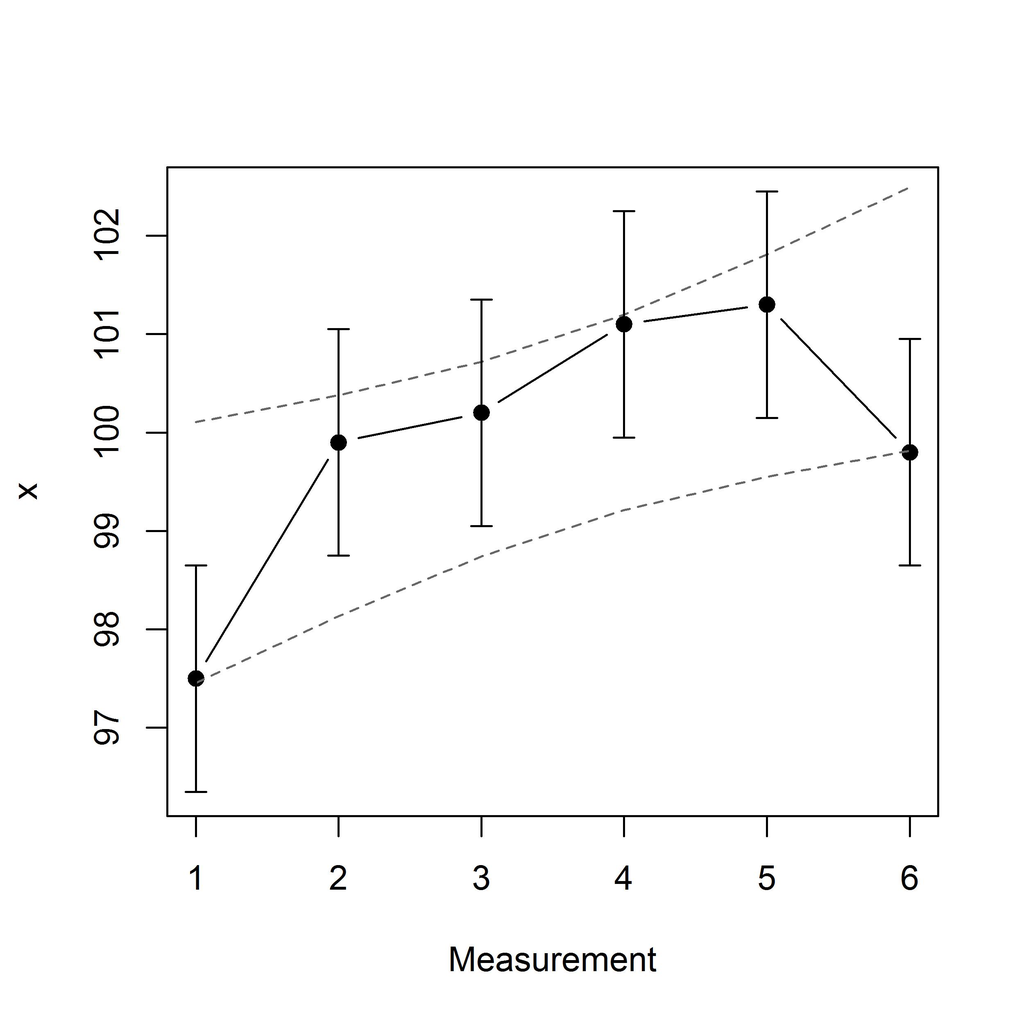

```r
df<-c(97.5,99.9,100.2,101.1,101.3,99.8)
mbir::swc_ind(x = df, swc = 0.25, type = "previous")
```

```r
## MBI From Previous Time Point:
##
##         Diff    N  T  P               MBI
## 1 - 2    2.4    8  4 88   Likely Increase
## 2 - 3    0.3   37 12 51               ---
## 3 - 4    0.9   26  9 65               ---
## 4 - 5    0.2   40 11 49               ---
## 5 - 6   -1.5   76  7 17               ---
```

Smallest worthwhile change argument requires users expertise regarding their particular data/athlete. With a lack of context, it would negligent to provide a default value for each situation. On the other hand, typical error defaults to the standard error of the linear regression residuals, but practitioners can certainly modify as needed.

Regarding the output table, from left to right, first describes the raw difference from preceding time point in ascending chronololgical order, followed by the probabilistic magnitude-based inference relating to the direction of change (“N” negative, decrease; “T” trivial; “P” positive, increase). On the far right are the qualitative inferences if detected (dashed lines represent *unclear* change, otherwise specified). The current example displays a *likely increase* from measurement 1 to measurement 2. Otherwise, no meaningful change was detected beyond time point 2.

Transitioning to the other offered analysis, “trend”, permits user to assess linear trajectory of measurements, as well as the degree of which each measurement deviates from the line of best fit. When “trend” is specified, users will be granted information regarding traditional regression statistics comparing values to a null model (in case of literature pursuit), such as: β coefficient (slope), *R*<sup>*2*</sup>, *F*-ratio and *p*-value. However, to apply magnitude-based inferences towards the linear trend requires an additional argument to specify; an anticipated slope (±) to test against.

For “trend” analysis, the syntactic structure of `swc_ind()` involves the following parameters:

- `x` numeric data vector of an individual’s performance measurements
- `swc` (±) smallest worthwhile change
- `type` “trend”
- `ts` (±) target slope

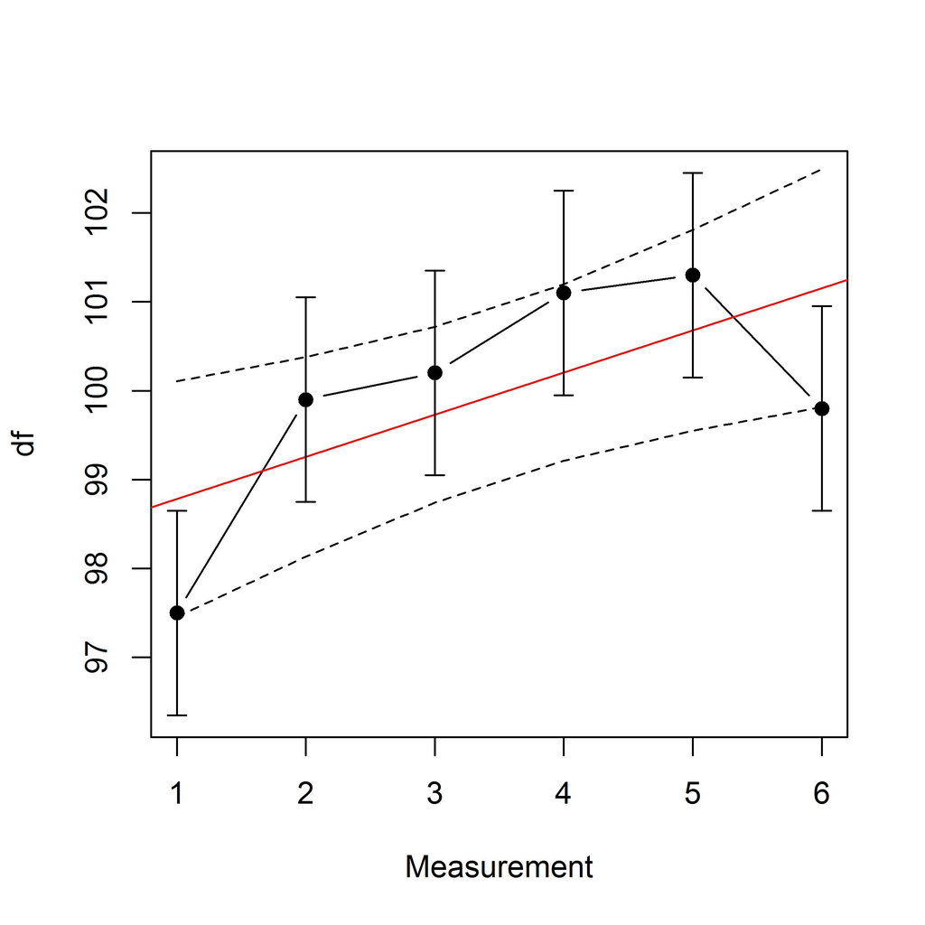

```r
mbir::swc_ind(x = df, swc = 0.25, ts = 0.2, type = "trend")
```

```r
##    Trend Parameters:
## Slope     0.474
## R-squared 0.283
## F stat    2.973
## P value   0.160
##
##         Very Unlikely Unlikely  Likely
##         "Decrease"    "Trivial" "Increase"
## MBI (%) "3"           "20"      "77"
##
##    MBI From Trend Line:
##
##  Point   Diff    N  T  P                  MBI
##      1   -1.3   88  7  5         Likely Lower
##      2    0.6   26 12 62                  ---
##      3    0.5   30 13 57                  ---
##      4    0.9   21 11 68                  ---
##      5    0.6   26 13 61                  ---
##      6   -1.4   90  5  5    Very Likely Lower
```

**References**

[^1]: Hopkins WG. sportsci.org.
[^2]: Hopkins WG, Marshall SW, Batterham AM & Hanin J. (2009). Progressive statistics for studies in sports medicine and exercise science. *Medicine & Science in Sports & Exercise*, 41, 3–13.
[^3]: Lang JM, Rothman KJ, & Cann CI. (1998). That confounded *P*-value. *Epidemiology*, 9, 7-8.
[^4]: Hedges LV. (1981). Distribution theory for Glass’s estimator of effect size and related estimators. *Journal of Educational Statistics*, 6, 107–128
[^5]: Altman DG. (1991). *Practical statistics for medical research*. London, UK: Chapman and Hall
[^6]: Hopkins WG. (2007). A spreadsheet for deriving a confidence interval, mechanistic inference and clinical inference from a *p* value. *Sportscience* 11, 16-20. sportsci.org/2007/wghinf.htm.
[^7]: Welsh AH & Knight EJ. (2015). “Magnitude-based inference”: A statistical review. *Medicine & Science in Sports & Exercise*, 47, 874-884.
[^8]: Barker RJ & Schofield MR. (2008). Inference about magnitudes of effects. *International Journal of Sports Physiology and Performance*, 3, 547-557.
[^9]: nflcombineresults.com
[^10]: Hopkins WG. (2007). A spreadsheet for deriving a confidence interval, mechanistic inference and clinical inference from a *p* value. *Sportscience* 11, 16-20. sportsci.org/2007/wghinf.htm.
[^11]: Hopkins WG. (2006). Estimating sample size for magnitude-based inferences. *Sportscience* 10, 63-70. sportsci.org/2006/wghss.htm
[^12]: Maxwell SE, Kelley K & Rausch JR. (2008). Sample size planning for statistical power and accuracy in parameter estimation. *Annual Review of Psychology*, 59, 537-563.
[^13]: Kelley K & Rausch JR. (2006). Sample size planning for the standardized mean difference: Accuracy in parameter estimation via narrow confidence intervals. *Psychological Methods*, 11, 363–385.
[^14]: Rosenthal R. (1994). Parametric measures of effect size. In H. Cooper & LV. Hedges (Eds.), *The Handbook of Research Synthesis*. New York, NY: Sage.
[^15]: Borenstein M, Hedges LV, Higgins JPT & Rothstein HR. (2009). *Introduction to Meta-Analysis*. Chichester, West Sussex, UK: Wiley.
[^16]: Hopkins WG. (2017). A spreadsheet for monitoring an individual’s changes and trend. *Sportscience* 21, 5-9. sportsci.org/2017/wghtrend.htm